# Exercise 5.8

Kári Hlynsson

2024-02-17

We will now perform cross-validation on a simulated data set.

## Part (a)

Generate a simulated data set as follows:

```r
set.seed(1)
x <- rnorm(100)
y <- x - 2 * x^2 + rnorm(100)
```

In this data set, what is $n$ and what is $p$? Write out the model used to generate the data in equation form.

#### Solution.

The data set is generated as per the code below:

```r
set.seed(1)
x <- rnorm(100)      # random covariate vector
e <- rnorm(100)      # random error vector
y <- x - 2 * x^2 + e # response
```

The model we have generated has $n = 100$ and $p = 2$, where

$$X_i \sim \mathcal N(0, 1) \quad \text{and} \quad Y_i \sim \mathcal N(X_i
- 2X_i^2, 1)\quad \forall i \in \{1, \ldots, 100\}.$$

## Part (b)

Create a scatter plot of $X$ against $Y$. Comment on what you find.

#### Solution.

Plot $X$ against $Y$ below:

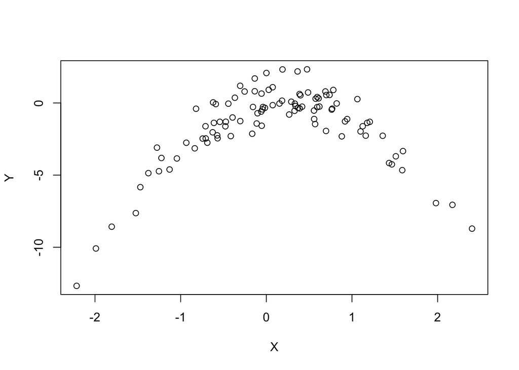

```r
plot(x, y, xlab = "X", ylab = "Y")
```

The above figure shows the random vectors which are distributed in a parabolic shape.

## Part (c)

Set a random seed, and then compute the LOOCV errors that result from fitting the following four models using least squares:

1. $\mathcal M_1: Y = \beta_0 + \beta_1 X + \epsilon$
2. $\mathcal M_2: Y = \beta_0 + \beta_1 X + \beta_2 X^2 + \epsilon$
3. $\mathcal M_3: Y = \beta_0 + \beta_1 X + \beta_2 X^2 + \beta_3 X^3 + \epsilon$
4. $\mathcal M_4: Y = \beta_0 + \beta_1 X + \beta_2 X^2 + \beta_3 X^3 + \beta_4 X^4 + \epsilon$

Note that you may find it helpful to use the `data.frame()` function to create a single data set containing both $X$ and $Y$.

#### Solution.

We will use the `cv.glm()` function to speed up things. This requires importing the `boot` package. I also use the `poly()` function when fitting the models with `raw` set to `TRUE` to use the raw polynomial basis and not an orthogonal polynomial basis.

```r
library(boot)
df <- data.frame(x, y)

# LOOCV for polynomials of degree 1-4
cv.res <- sapply(1:4, function(d) {
  glm.fit <- glm(y ~ poly(x, d, raw = TRUE), data = df)
  loocv <- cv.glm(df, glm.fit)$delta

  names(loocv) <- c("raw", "biased")
  return(list(loocv, glm.fit))
})

# bind CV errors into table
cv_errs <- do.call(cbind, cv.res[1,])
colnames(cv_errs) <- paste0("model", 1:4)

# extract model objects from cv.res
models <- cv.res[2,]

cv_errs
```

```
##          model1    model2    model3    model4
## raw    7.288162 0.9374236 0.9566218 0.9539049
## biased 7.284744 0.9371789 0.9562538 0.9534453
```

The cross validation errors (i.e. raw and biased) are virtually identical for each model, so there does not seem to be any induced bias in the LOOCV process.

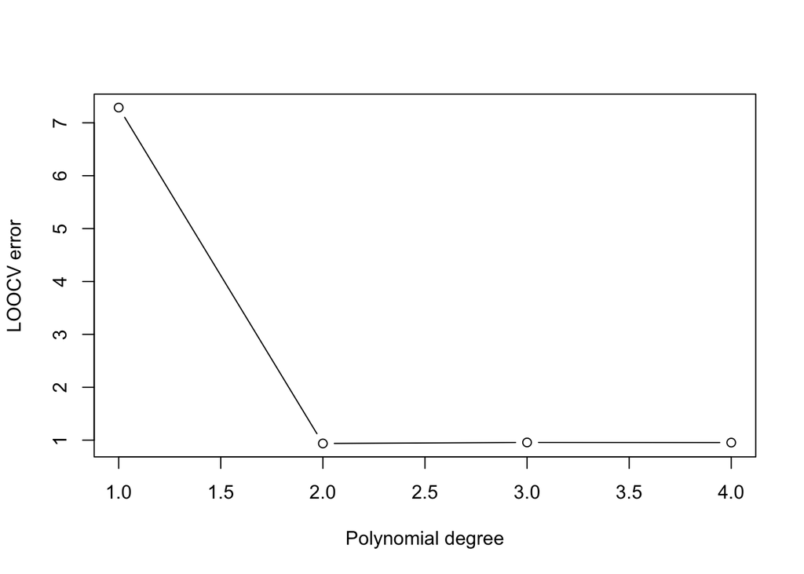

```r
plot(1:4, cv_errs[1,], type = "b", xlab = "Polynomial degree", ylab = "LOOCV error")
```

Let’s see which model minimises the LOOCV error:

```r
which.min(cv_errs[1,])
```

```
## model2
##      2
```

It is $\mathcal M_2$. Upon including the quadratic term most of the variance in the data is explained. We can see this by performing an F test. This test works by comparing the variance in the data explained by the model, in this case sequentially across the models $\mathcal M_1, \mathcal M_2, \mathcal M_3$ and $\mathcal M_4$:

```r
do.call(anova, c(models, test = "F"))
```

```
## Analysis of Deviance Table
##
## Model 1: y ~ poly(x, d, raw = TRUE)
## Model 2: y ~ poly(x, d, raw = TRUE)
## Model 3: y ~ poly(x, d, raw = TRUE)
## Model 4: y ~ poly(x, d, raw = TRUE)
##   Resid. Df Resid. Dev Df Deviance        F Pr(>F)
## 1        98     662.55
## 2        97      89.03  1   573.52 623.5421 <2e-16 ***
## 3        96      88.96  1     0.07   0.0758 0.7836
## 4        95      87.38  1     1.58   1.7181 0.1931
## ---
## Signif. codes:  0 '***' 0.001 '**' 0.01 '*' 0.05 '.' 0.1 ' ' 1
```

From the above output we see that model 2 is favourable to model 1. However the same can not be said when comparing models 3 and 4 to model 2. Therefore, the quadratic term seems to be most suitable, which is what one would expect. It helps to display the models visually against the data to get a feel for how the fit changes with an increase in polynomial degree.

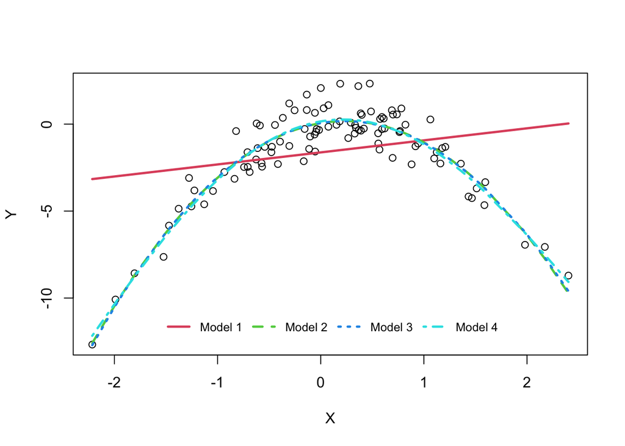

```r
# plot all the polynomial fits against the data
plot(df$x, df$y, xlab = "X", ylab = "Y")
catch <- sapply(1:4, function(d) {
  poly.mdl  <- models[[d]]
  poly.pred <- predict(poly.mdl, df)
  ord <- order(x)

  lines(x[ord], poly.pred[ord], col = d + 1, lwd = 2.5, lty = d)
})

legend("bottom", inset = c(0.05, 0.05), legend = paste("Model", 1:4), horiz = TRUE,
       lwd = 2.5, col = 2:5, lty = 1:4, cex = 0.8, bty = "n")
```

Here we see that model 1 does a very poor job of describing the data, whereas models 2, 3 and 4 are nearly identical fits. This would indeed motivate us to use the quadratic model, $\mathcal M_2$, by the law of parsimony.

## Part (d)

Repeat (c) using another random seed, and report your results. Are your results the same as what you got in (c)? Why?

#### Solution.

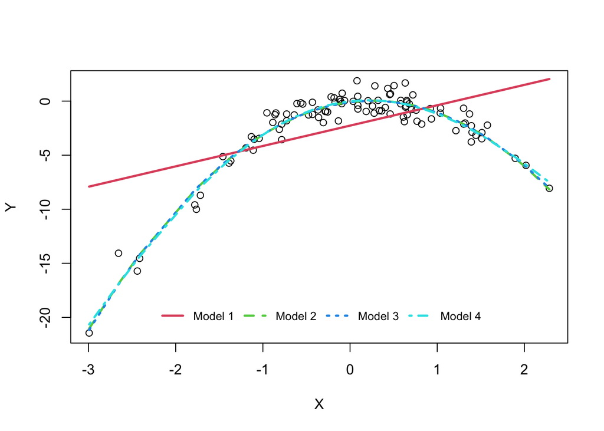

```r
set.seed(42)
x <- rnorm(100) # new covariate vector
y <- x - 2 * x^2 + rnorm(100)

df <- data.frame(x, y)

# LOOCV for polynomials of degree 1-4
cv.res <- sapply(1:4, function(d) {
  glm.fit <- glm(y ~ poly(x, d, raw = TRUE), data = df)
  loocv <- cv.glm(df, glm.fit)$delta

  names(loocv) <- c("raw", "biased")
  return(list(loocv, glm.fit))
})

# gather CV errors into table
cv_errs <- do.call(cbind, cv.res[1,])
colnames(cv_errs) <- paste0("model", 1:4)

# new fitted polynomial objects
models <- cv.res[2,]

# plot the polynomial fits against the data
plot(df$x, df$y, xlab = "X", ylab = "Y")
catch <- sapply(1:4, function(d) {
  poly.mdl  <- models[[d]]
  poly.pred <- predict(poly.mdl, df)
  ord <- order(x)

  lines(x[ord], poly.pred[ord], col = d + 1, lwd = 2.5, lty = d)
})

legend("bottom", inset = c(0.05, 0.05), legend = paste("Model", 1:4), horiz = TRUE,
       lwd = 2.5, col = 2:5, lty = 1:4, cex = 0.8, bty = "n")
```

## Part (e)

Which of the models in (c) had the smallest LOOCV error? Is that what you expected? Explain your answer.

#### Solution.

In part (c) we saw that the quadratic polynomial yielded the smallest LOOCV error. This is to be expected since the underlying model is a quadratic polynomial in $x$.

## Part (f)

Comment on the statistical significance of the coefficient estimates that results from fitting each of the models in (c) using least squares. Do these results agree with the conclusions drawn based on the cross-validation results?

#### Solution.

We conducted an F test to compare the explained variance by the models and concluded that model 2 was the most powerful. We can also see this from the outputs of the models objects.

```r
summary(models[[2]])
```

```
##
## Call:
## glm(formula = y ~ poly(x, d, raw = TRUE), data = df)
##
## Coefficients:
##                         Estimate Std. Error t value Pr(>|t|)
## (Intercept)             -0.09625    0.11254  -0.855    0.395
## poly(x, d, raw = TRUE)1  1.03026    0.09183  11.220   <2e-16 ***
## poly(x, d, raw = TRUE)2 -1.99276    0.06039 -32.996   <2e-16 ***
## ---
## Signif. codes:  0 '***' 0.001 '**' 0.01 '*' 0.05 '.' 0.1 ' ' 1
##
## (Dispersion parameter for gaussian family taken to be 0.8334462)
##
##     Null deviance: 1369.191  on 99  degrees of freedom
## Residual deviance:   80.844  on 97  degrees of freedom
## AIC: 270.52
##
## Number of Fisher Scoring iterations: 2
```

```r
summary(models[[3]])
```

```
##
## Call:
## glm(formula = y ~ poly(x, d, raw = TRUE), data = df)
##
## Coefficients:
##                         Estimate Std. Error t value Pr(>|t|)
## (Intercept)             -0.10288    0.11527  -0.892    0.374
## poly(x, d, raw = TRUE)1  0.99342    0.15505   6.407  5.5e-09 ***
## poly(x, d, raw = TRUE)2 -1.98058    0.07333 -27.007  < 2e-16 ***
## poly(x, d, raw = TRUE)3  0.01237    0.04183   0.296    0.768
## ---
## Signif. codes:  0 '***' 0.001 '**' 0.01 '*' 0.05 '.' 0.1 ' ' 1
##
## (Dispersion parameter for gaussian family taken to be 0.8413617)
##
##     Null deviance: 1369.191  on 99  degrees of freedom
## Residual deviance:   80.771  on 96  degrees of freedom
## AIC: 272.43
##
## Number of Fisher Scoring iterations: 2
```

```r
summary(models[[4]])
```

```
##
## Call:
## glm(formula = y ~ poly(x, d, raw = TRUE), data = df)
##
## Coefficients:
##                         Estimate Std. Error t value Pr(>|t|)
## (Intercept)             -0.01804    0.13311  -0.136    0.892
## poly(x, d, raw = TRUE)1  0.91167    0.16757   5.440 4.13e-07 ***
## poly(x, d, raw = TRUE)2 -2.17063    0.16728 -12.976  < 2e-16 ***
## poly(x, d, raw = TRUE)3  0.05941    0.05591   1.063    0.291
## poly(x, d, raw = TRUE)4  0.03906    0.03092   1.263    0.210
## ---
## Signif. codes:  0 '***' 0.001 '**' 0.01 '*' 0.05 '.' 0.1 ' ' 1
##
## (Dispersion parameter for gaussian family taken to be 0.8361751)
##
##     Null deviance: 1369.191  on 99  degrees of freedom
## Residual deviance:   79.437  on 95  degrees of freedom
## AIC: 272.77
##
## Number of Fisher Scoring iterations: 2
```

In all of the summaries the linear and quadratic terms are significant, but neither the cubic or the quartic term are significant. This is the same result as the one produced by the F test in part (c).